# ggplot2

## Adding a coordinate system

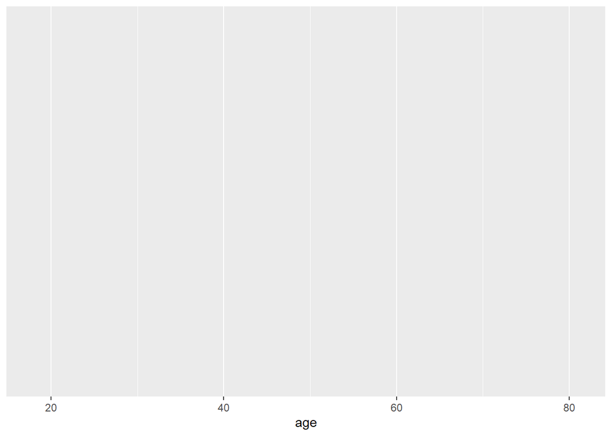

```r
ggplot(df, aes(x = age))
```

> Great! We have now mapped the variable age onto the x axis - now lets try adding some geoms such as geom_dotplot

## Adding a geom (dotplot)

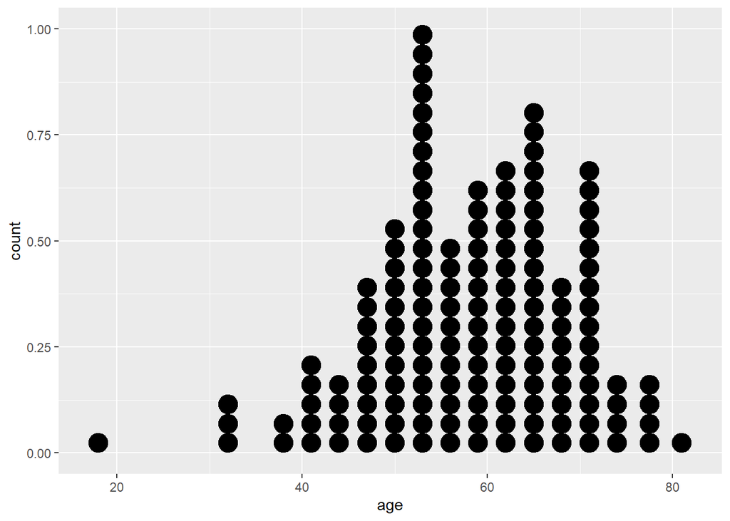

```r
ggplot(df, aes(x = age)) +
  geom_dotplot()
```

### Making changes to the geom layer

> Great! Our first plot - it doesn’t look very pretty such as the dots being very large spanning multiple age points. Let’s update the plot using some of the arguments available inside `geom_dotplot()`. I don’t remember all of the available arguments, lets look up the documentation using ?geom_dotplot

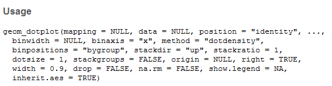

> A couple things to highlight, we want to use the histodot function because we want fixed binwidth instead of the default ‘dotdensity’ approach, we also want to adjust binwidht to 1 indicating 1 stacked column of dots per every age

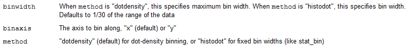

> Let’s make those changes

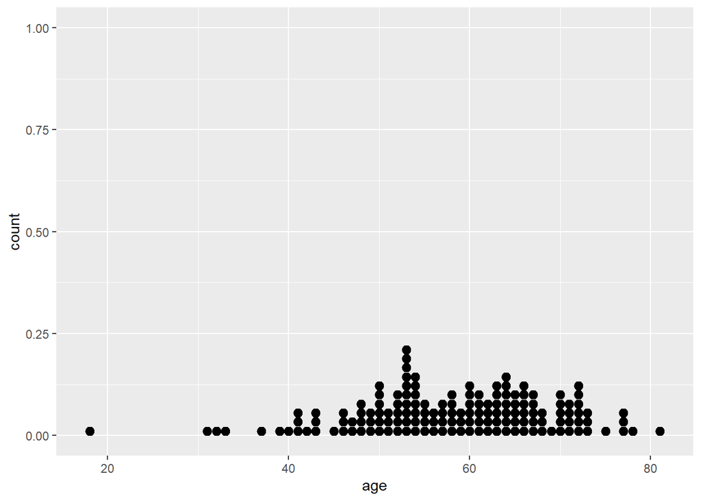

```r
ggplot(df, aes(x = age)) +
  geom_dotplot(method = 'histodot', binwidth = 1)
```

> Great! This is looking more like a dotplot, but it still doesn’t look very pretty. It’s very grey and dull, Let’s spice things up with themes.

## Themes

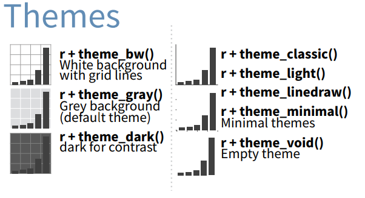

> Some of the default themes that come from ggplot2, but there are many more that we can utilize from the ggthemes package!

https://cran.r-project.org/web/packages/ggthemes/vignettes/ggthemes.html

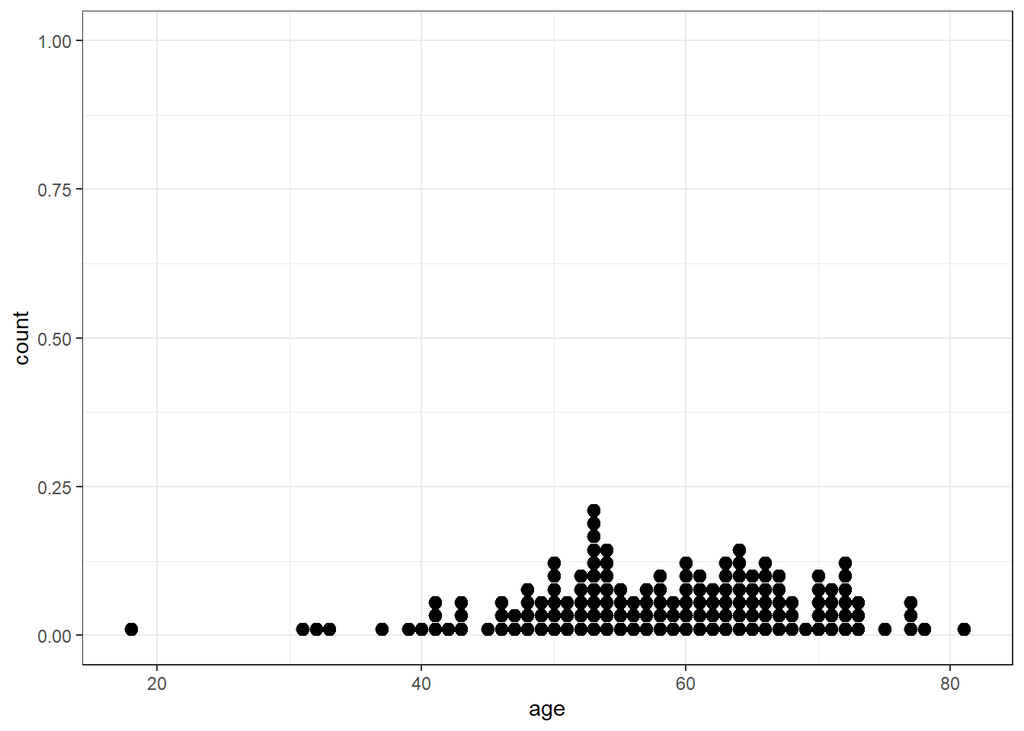

```r
ggplot(df, aes(x = age)) +
  geom_dotplot(binwidth = 1, method = "histodot") +
  theme_bw()
```

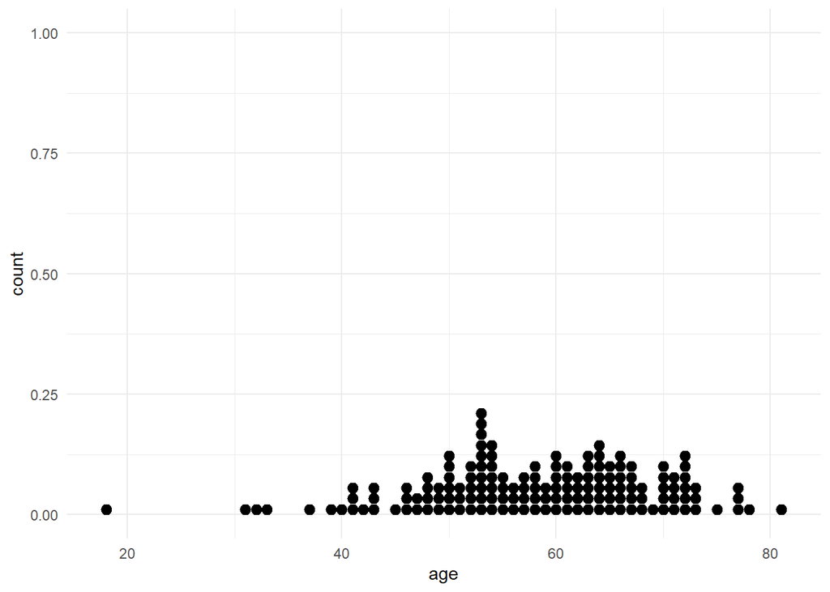

```r
ggplot(df, aes(x = age)) +
  geom_dotplot(binwidth = 1, method = "histodot") +
  theme_minimal()
```

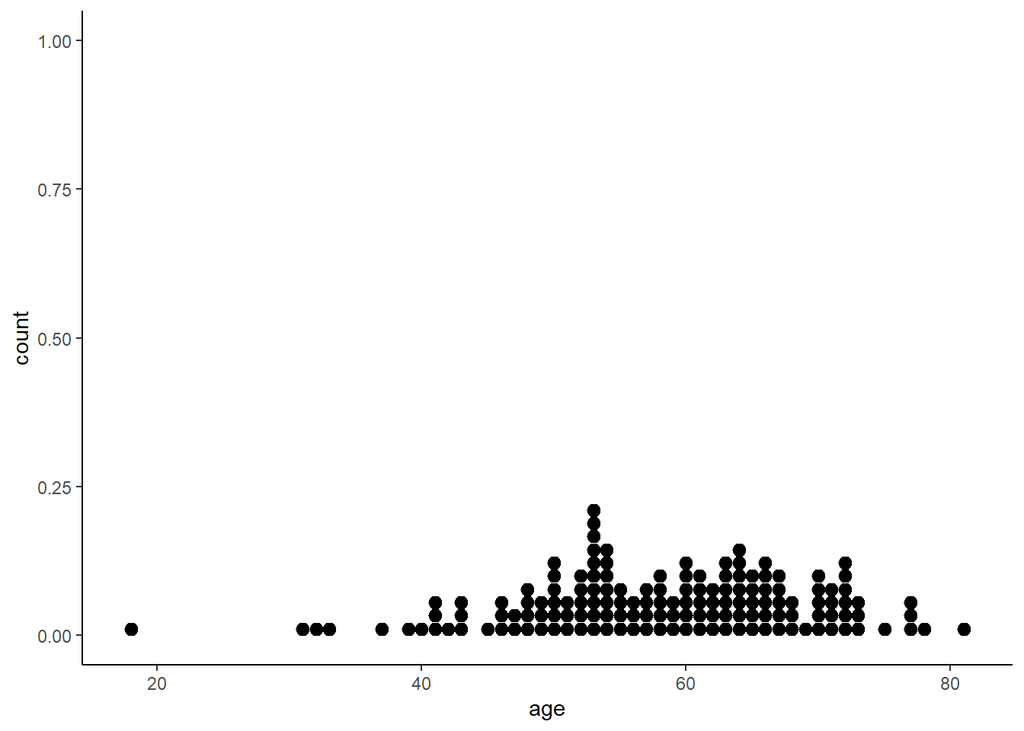

```r
ggplot(df, aes(x = age)) +
  geom_dotplot(binwidth = 1, method = "histodot") +
  theme_classic()
```

### Utilizing themes from the ggthemes package

> Utilizing themes from the ggthemes package, if you dont have ggthemes then please install using `install.packages('ggthemes')` and loading up the library using `library(ggthemes)`. I’ve commented out `#install.packages('ggthemes')` because I already have it. The # is used as a method to make comments in your code.

#### Fivethirtyeight theme

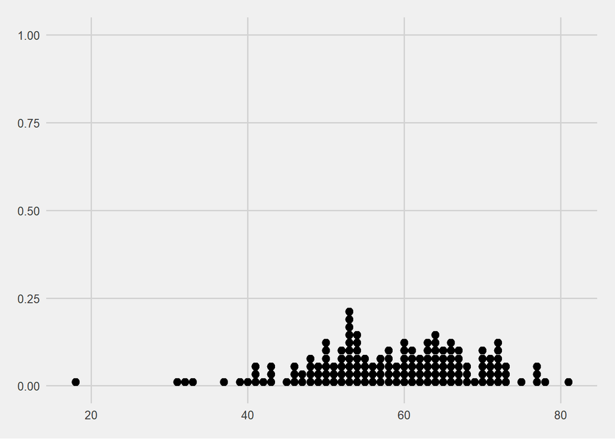

```r
# install.packages('ggthemes')
library(ggthemes)

# Theme matching the popular politics/analytics website firvethirtyeight
ggplot(df, aes(x = age)) +
  geom_dotplot(binwidth = 1, method = "histodot") +
  theme_fivethirtyeight()
```

#### Wallstreet journal theme

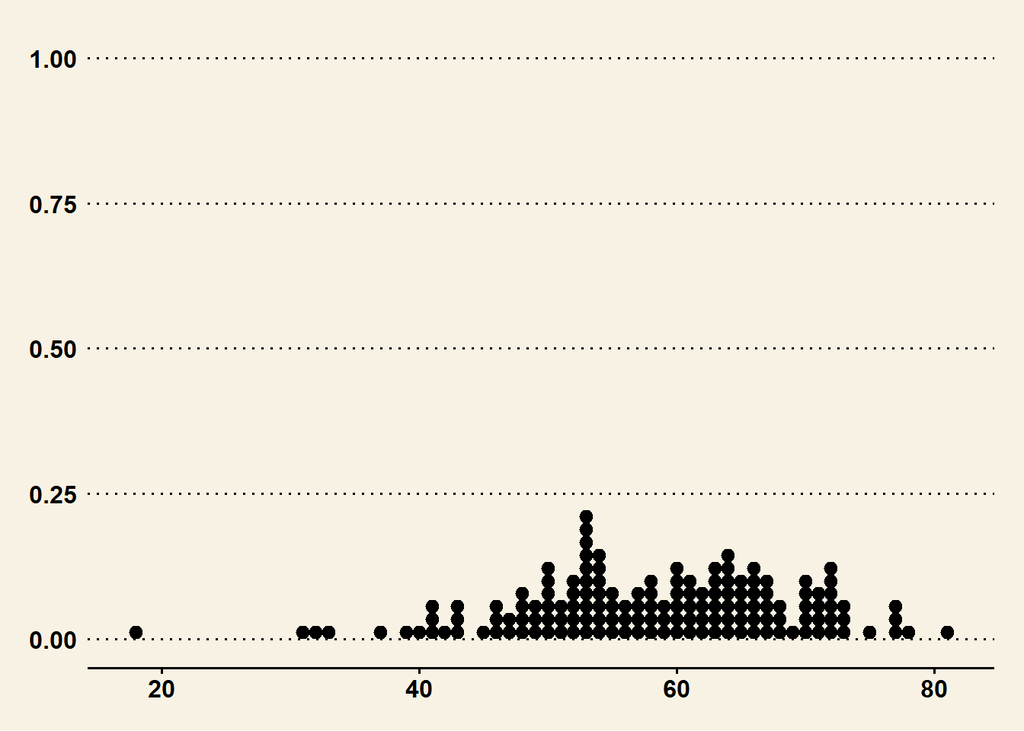

```r
# Wallstreet journal
ggplot(df, aes(x = age)) +
  geom_dotplot(binwidth = 1, method = "histodot") +
  theme_wsj()
```

#### Economist theme

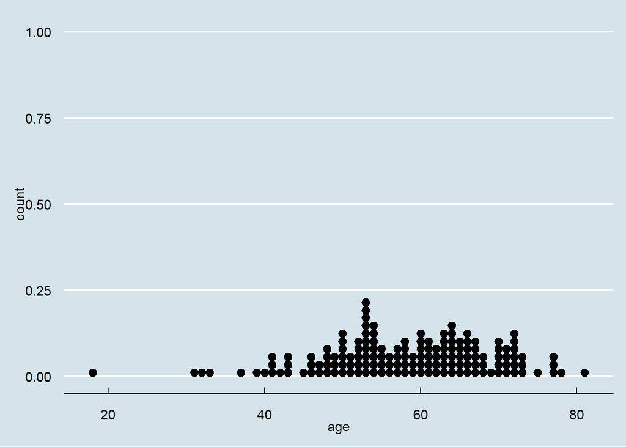

```r
# Economist
ggplot(df, aes(x = age)) +
  geom_dotplot(binwidth = 1, method = "histodot") +
  theme_economist()
```

#### Excel theme

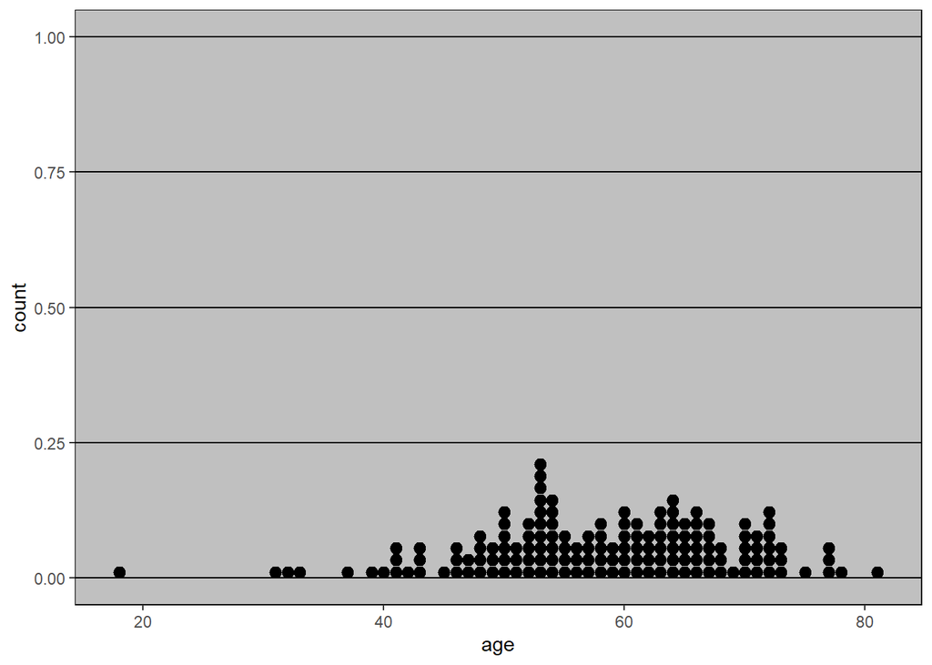

```r
# Excel

ggplot(df, aes(x = age)) +
  geom_dotplot(binwidth = 1, method = "histodot") +
  theme_excel()
```

### Customizing a theme

> Lets continue on with theme_bw(), but make some customizations with the `theme()` function, by removing the ticks, the title, and the text for the y axis.

> We can do this by looking at the documentation for `theme()` using `?theme`

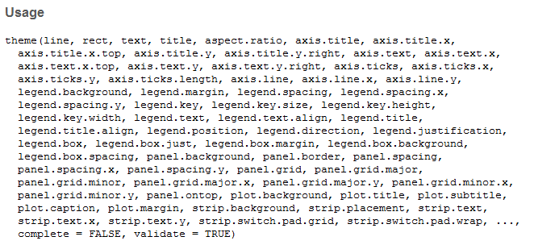

> There are ALOT of possible customizations we can make, but we will focus on the `axis.title.y`, `axis.text.y`, and the `axis.ticks.y` arguments.

> Almost all arguments in `theme()` needs to receive the information with the `element_blank()`, `element_text()`, `element_line()`, and `element_rect()` function. We will focus on `element_blank()` for now by using it to remove the information on the y axis.

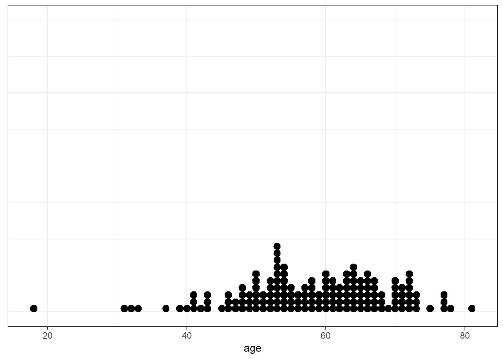

```r
ggplot(df, aes(x = age)) +
  geom_dotplot(binwidth = 1, method = "histodot") +
  theme_bw() +
  theme(axis.title.y = element_blank(),
        axis.text.y = element_blank(),
        axis.ticks.y = element_blank())
```

#### Adding and customizing the colors using the fill argument and the scale_fill_manual() / scale_fill_discrete() function

> Looks more like a dotplot now! But how about adding some color, by identifying the infection and non infection patients. We can do this using the `fill` argument and mapping it to the variable infection. Recall if we want to map any variables, we can only map those varaibles within the `aes()` argument.

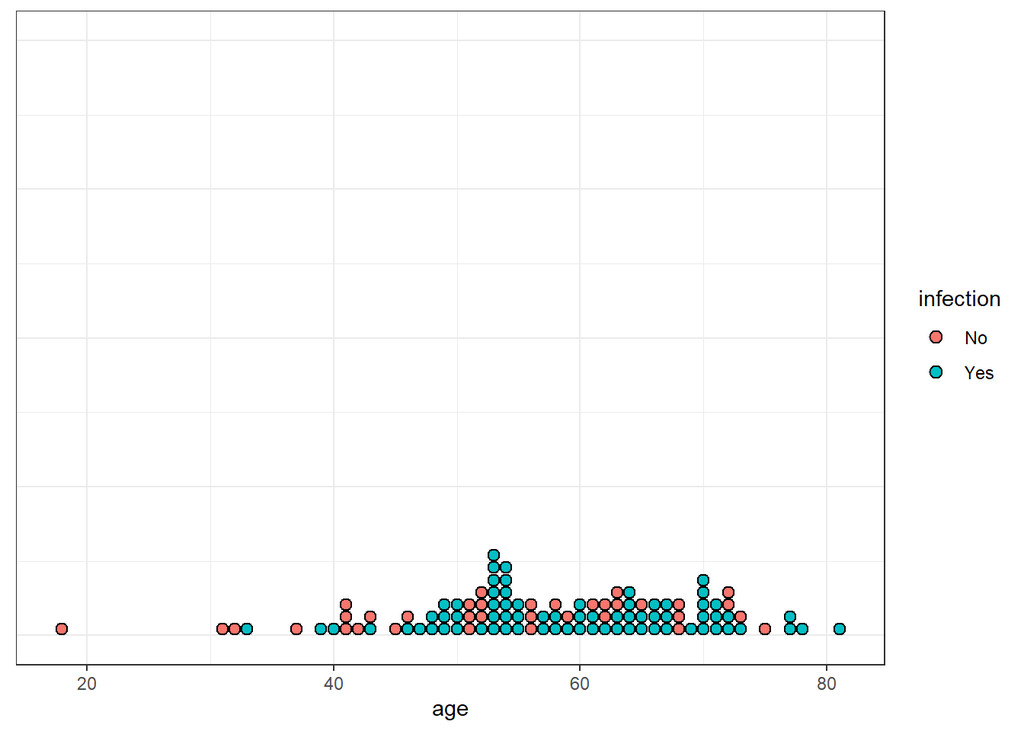

```r
ggplot(df, aes(x = age, fill = infection)) +
  geom_dotplot(binwidth = 1, method = "histodot") +
  theme_bw() +
  theme(axis.title.y = element_blank(),
        axis.text.y = element_blank(),
        axis.ticks.y = element_blank())
```

> Looks great but the x axis label ‘age’ doesn’t look very good, lets capitalize it and fix the legend title so it’ll be more ‘tidy’. It doesn’t look very ‘publication ready’, because we can do better!. We can do this by using the `labs()` function, and changing the x axis label. Since the color legend is mapped using the `fill` argument, we can make changes to the title by specifying it with the `scale_fill_discrete()` function.

#### Customizing the x axis title and the legend title

> `scale_fill_discrete()` changes the scale name of the fill function manually as well as other options (Please see the documentation for further customization details!), but we’ll focus on changing the name for now. By default, it uses the variable name but in this case we want to change it to something more pleasing and consistent with the rest of the plot.

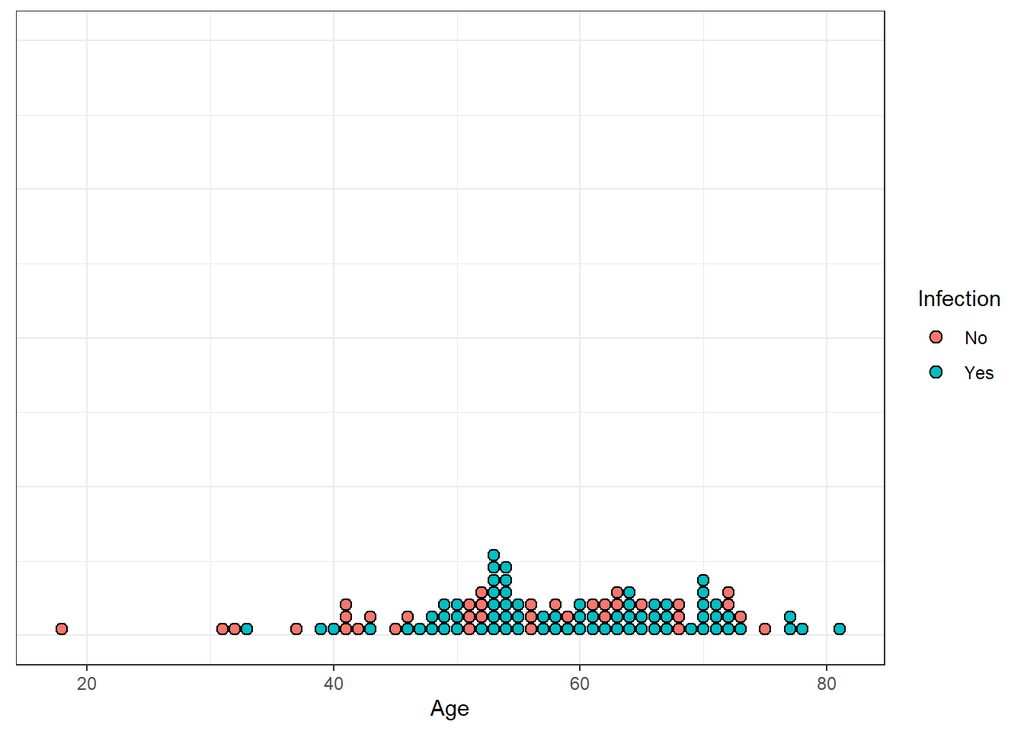

```r
ggplot(df, aes(x = age, fill = infection)) +
  geom_dotplot(binwidth = 1, method = "histodot")  +
  theme_bw() +
  theme(axis.title.y = element_blank(),
        axis.text.y = element_blank(),
        axis.ticks.y = element_blank()) +
  scale_fill_discrete("Infection") +
  labs(x = "Age")
```

> Legend title is now fixed - however what if we want to have custom colors ? We can use the `scale_fill_manual()` instead of `scale_fill_discrete()` because we want to specify the colors manually via the values argument. Let’s change it to black and green to see how it looks.

#### Manually specifying colors via `scale_fill_manual()`

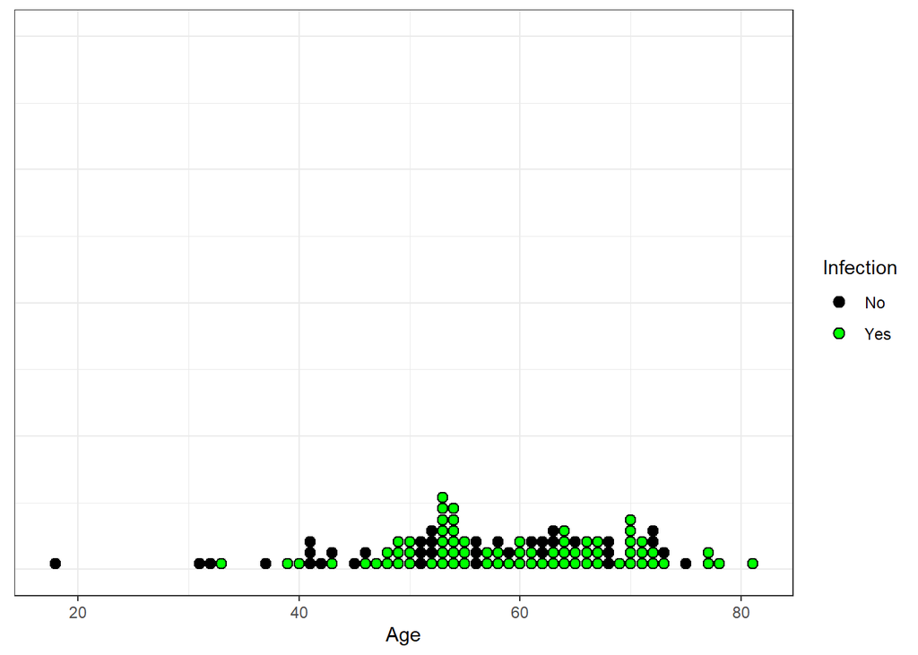

```r
ggplot(df, aes(x = age, fill = factor(infection))) +
  geom_dotplot(binwidth = 1, method = "histodot")  +
  theme_bw() +
  theme(axis.title.y = element_blank(),
        axis.text.y = element_blank(),
        axis.ticks.y = element_blank()) +
  scale_fill_manual("Infection", values = c('black', 'green')) +
  labs(x = "Age")
```

#### Customizing the colors using palletes

> ggplot2 has a selection of built in color palletes so you dont have to specify your own, that are ‘aesthetically pleasing’

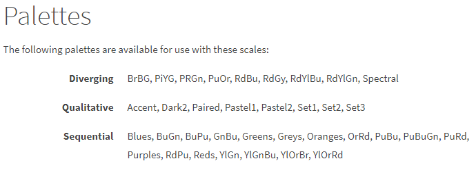

Examples can be found on the ggplot2 tidyverse site http://ggplot2.tidyverse.org/reference/scale_brewer.html

> We can specify the color pallete using the `scale_fill_brewer()` function. We will have to also include the updated scale name ‘Infection’ that way our legend title has the capitalized ‘I’.

##### Set3

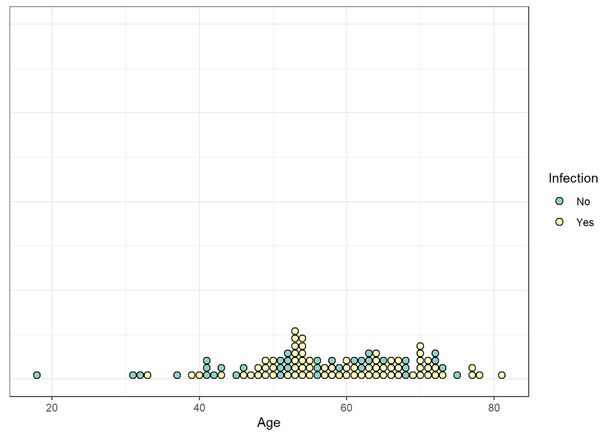

```r
ggplot(df, aes(x = age, fill = infection)) +
  geom_dotplot(binwidth = 1, method = "histodot")  +
  theme_bw() +
  theme(axis.title.y = element_blank(),
        axis.text.y = element_blank(),
        axis.ticks.y = element_blank()) +
  scale_fill_brewer("Infection", palette = "Set3") +
  labs(x = "Age")
```

##### Set2

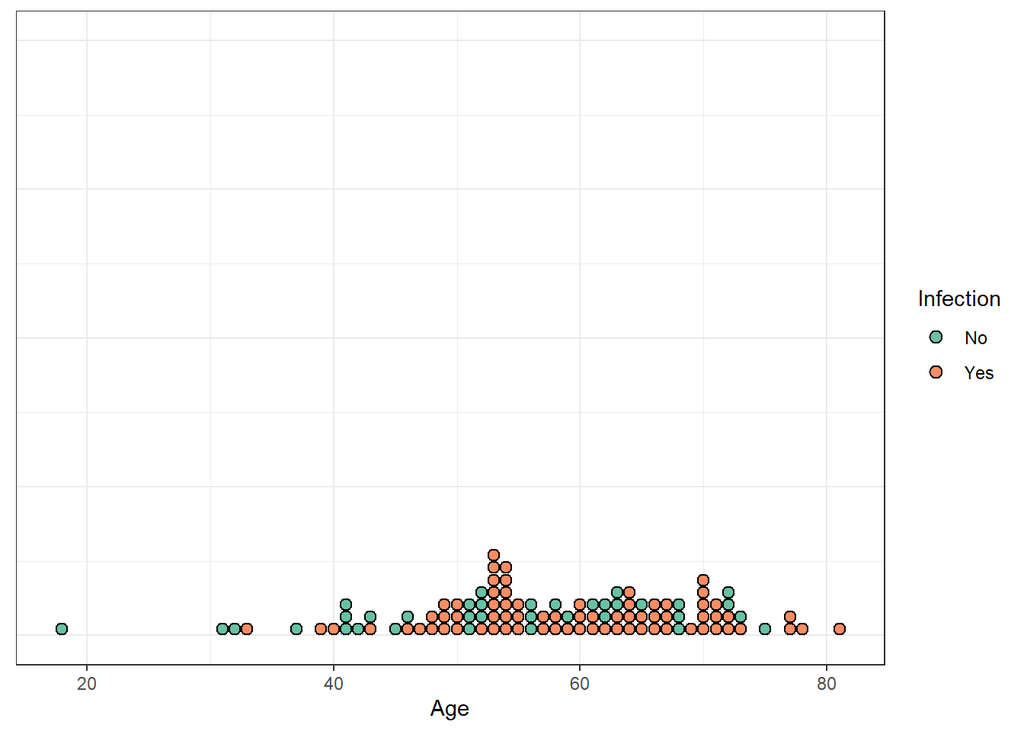

```r
ggplot(df, aes(x = age, fill = infection)) +
  geom_dotplot(binwidth = 1, method = "histodot")  +
  theme_bw() +
  theme(axis.title.y = element_blank(),
        axis.text.y = element_blank(),
        axis.ticks.y = element_blank()) +
  scale_fill_brewer("Infection", palette = "Set2") +
  labs(x = "Age")
```

##### Set1

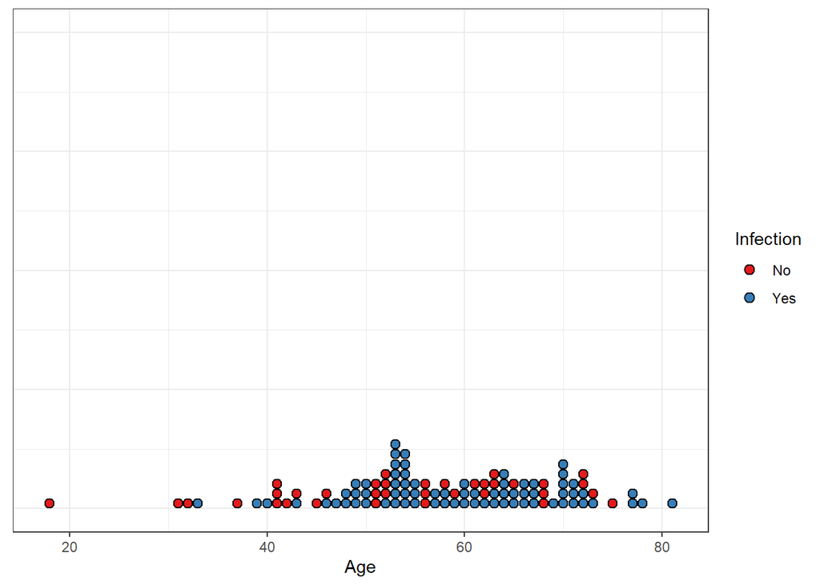

```r
ggplot(df, aes(x = age, fill = infection)) +
  geom_dotplot(binwidth = 1, method = "histodot")  +
  theme_bw() +
  theme(axis.title.y = element_blank(),
        axis.text.y = element_blank(),
        axis.ticks.y = element_blank()) +
  scale_fill_brewer("Infection", palette = "Set1") +
  labs(x = "Age")
```

> Let’s choose ‘Set1’ as our color pallete.

> What if we don’t want the dots to be stacked? We can utilize the facet option to stratify the infection and non infection patients into separate panels or ‘facets’

## Utilizing ‘Facets’ to separate our dotplot into groups

> We can use the `facet_grid()` function, this will stratify the dotplot by a selected variable such as `infection` by it’s levels such as ‘Yes’, and ‘No’

> Lets look at the documentation again

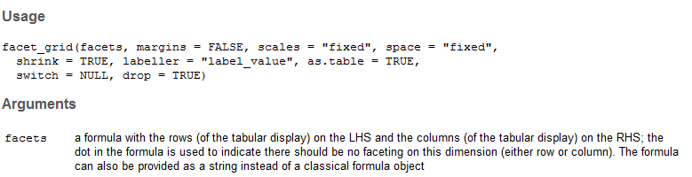

> We will focus on the facets argument, which per the documentation requires a formula specifying the LHS (left hand side) and the RHS (right hand side) corresponding to rows ~ columns. A . (period) can be used as a placeholder indicating no ‘facet’ on that level. We can facet by columns upon the infection variable by indicating this formula `. ~ infection` in the `facet_grid()` function.

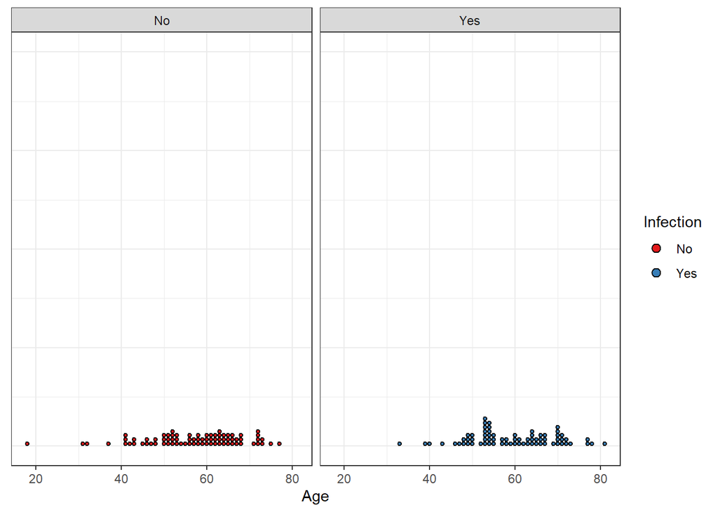

```r
ggplot(df, aes(x = age, fill = infection)) +
  geom_dotplot(binwidth = 1, method = "histodot")  +
  theme_bw() +
  theme(axis.title.y = element_blank(),
        axis.text.y = element_blank(),
        axis.ticks.y = element_blank()) +
  scale_fill_brewer("Infection", palette = "Set1") +
  labs(x = "Age") +
  facet_grid(. ~ infection)
```

> Lets try facet on the row to see how it looks. We can do this by flipping the formula by placing the variable infection on the LHS.

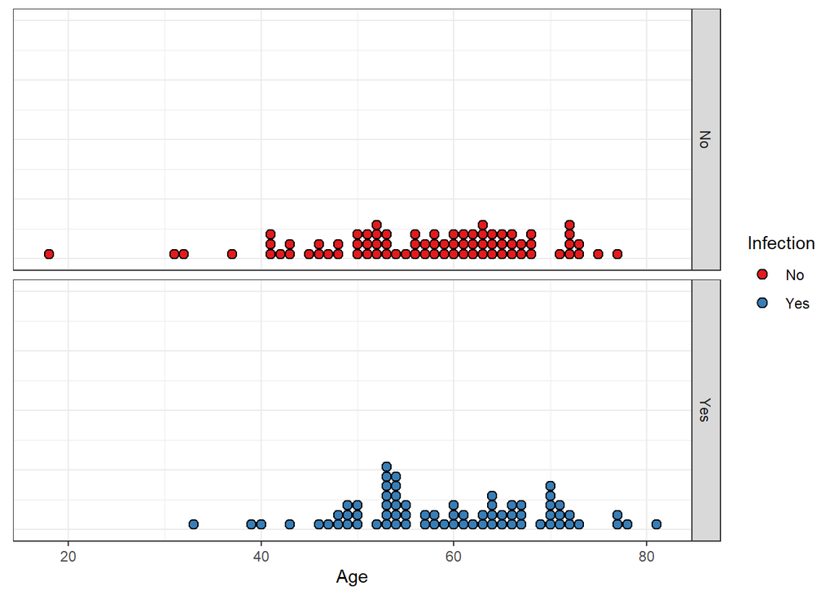

```r
ggplot(df, aes(x = age, fill = infection)) +
  geom_dotplot(stackgroups = TRUE, binwidth = 1, method = "histodot")  +
  theme_bw() +
  theme(axis.title.y = element_blank(),
        axis.text.y = element_blank(),
        axis.ticks.y = element_blank()) +
  scale_fill_brewer("Infection", palette = "Set1") +
  labs(x = "Age") +
  facet_grid(infection ~ .)
```

> Now that we have faceted the plot, the legend isn’t very informative anymore and its redundant. Lets remove it!

## Removing the legend

> The legend argument is found within the `theme()` function with the argument `legend.position`. This argument has multiple uses, we would like to remove it.

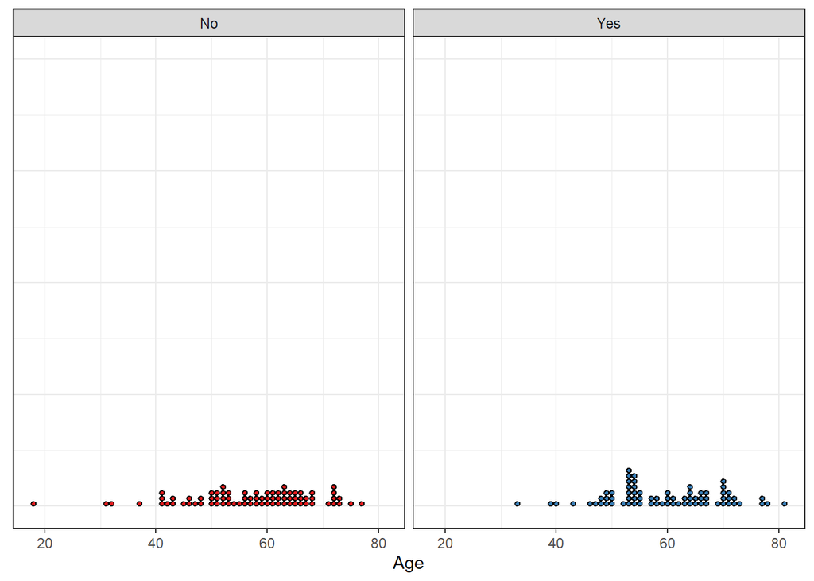

```r
ggplot(df, aes(x = age, fill = infection)) +
  geom_dotplot(binwidth = 1, method = "histodot")  +
  theme_bw() +
  theme(axis.title.y = element_blank(),
        axis.text.y = element_blank(),
        axis.ticks.y = element_blank(),
        legend.position = "none") +
  scale_fill_brewer("Infection", palette = "Set1") +
  labs(x = "Age") +
  facet_grid(. ~ infection)
```

> The plot is really starting to come together, but what if we want to change the scale of the x axis ? A scale/label on the x axis at every 5 years may be more informative than every 20 years.

## Changing the x axis scale

> We can do this by utilizing the `scale_x_continuous()` function. Per the documentation, one of the arguments is `breaks` which specifies the breaks in the scale and it requires a vector of numbers for the breaks. We can specify it by typing `c(15, 20, 25, ...)` but as programmers we are lazy, and can utilizing the `seq()` function which returns a vector of numbers from a specified range. `seq(0, 100, 1)` will produce a vector of numbers from 0 to 100 by 1.

```r
seq(0,100,1)
```

```
  [1]   0   1   2   3   4   5   6   7   8   9  10  11  12  13  14  15  16  17
 [19]  18  19  20  21  22  23  24  25  26  27  28  29  30  31  32  33  34  35
 [37]  36  37  38  39  40  41  42  43  44  45  46  47  48  49  50  51  52  53
 [55]  54  55  56  57  58  59  60  61  62  63  64  65  66  67  68  69  70  71
 [73]  72  73  74  75  76  77  78  79  80  81  82  83  84  85  86  87  88  89
 [91]  90  91  92  93  94  95  96  97  98  99 100
```

> We can use this in the breaks argument as shown below to specify the range. ggplot2 is smart that it will limit the view of the x axis that is within reasonable range of the data. Just to be safe we’ll use `seq(from = 0, to = 100, by = 5)` to create a vector of numbers from 0 to 100 by 5

> Note! You can also change the y axis scale with a similar function called `scale_y_continuous()`

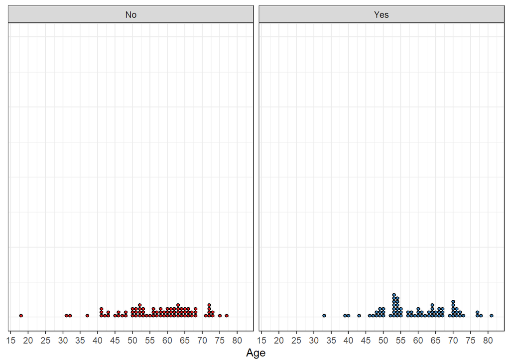

```r
ggplot(df, aes(x = age, fill = infection)) +
  geom_dotplot(binwidth = 1, method = "histodot", binpositions="bygroup")  +
  theme_bw() +
  theme(axis.title.y = element_blank(),
        axis.text.y = element_blank(),
        axis.ticks.y = element_blank(),
        legend.position = "none") +
  scale_fill_brewer("Infection", palette = "Set1") +
  labs(x = "Age") +
  facet_grid(. ~ infection) +
  scale_x_continuous(breaks = seq(0,100, 5))
```